# Data Wrangling

Rohan Kalu

# Data Wrangling

• Load necessary package

```r
library(dplyr)
```

```r
library(magrittr)
library(ggplot2)
library(readr)
library(lubridate)
```

• Load the dataset

```r
accidents <- read.csv("data/accidents.csv")
guidance <- read.csv("data/guidance.csv")
```

• Check the first 6 data of the csv

```r
head(accidents)
```

|  | Number.of.Vehicles | Accident.Date | Time..24hr. | X1st.Road.Class | Road.Surface | Lighting.Conditions | Daylight.Dark | Weather.Conditions | Local.Authority | Type.of.Vehicle | Casualty.Class | Casualty.Severity | Sex.of.Casualty | Age.of.Casualty |
| --- | --- | --- | --- | --- | --- | --- | --- | --- | --- | --- | --- | --- | --- | --- |
| 1 | 2 | 1/1/2017 | 2120 | U | Wet/Damp | 4 | Dark | 2 | Calderdale | 9 | 2 | 2 | 2 | 16 |
| 2 | 2 | 4/1/2017 | 1500 | U | Dry | 1 | Daylight | 1 | Calderdale | 9 | 3 | 2 | 2 | 67 |
| 3 | 2 | 5/1/2017 | 732 | A58 | Wet/Damp | 4 | Dark | 1 | Calderdale | 9 | 1 | 3 | 1 | 56 |
| 4 | 2 | 5/1/2017 | 930 | A646 | Wet/Damp | 1 | Daylight | 1 | Calderdale | 4 | 1 | 1 | 1 | 20 |
| 5 | 2 | 14/01/2017 | 909 | U | Frost/Ice | 1 | Daylight | 1 | Calderdale | 9 | 1 | 3 | 1 | 46 |
| 6 | 1 | 15/01/2017 | 1659 | U | Wet/Damp | 4 | Dark | 1 | Calderdale | 9 | 3 | 3 | 1 | NA |

• Check dimension, structure and summary of the data

```r
dim(accidents)
```

```
## [1] 2069   14
```

```r
str(accidents)
```

```
## 'data.frame':    2069 obs. of  14 variables:
##  $ Number.of.Vehicles : int  2 2 2 2 2 1 1 3 1 1 ...
##  $ Accident.Date      : chr  "1/1/2017" "4/1/2017" "5/1/2017" "5/1/2017" ...
##  $ Time..24hr.        : int  2120 1500 732 930 909 1659 1059 1849 1408 1325 ...
##  $ X1st.Road.Class    : chr  "U" "U" "A58" "A646" ...
##  $ Road.Surface       : chr  "Wet/Damp" "Dry" "Wet/Damp" "Wet/Damp" ...
##  $ Lighting.Conditions: int  4 1 4 1 1 4 1 4 1 1 ...
##  $ Daylight.Dark      : chr  "Dark" "Daylight" "Dark" "Daylight" ...
##  $ Weather.Conditions : int  2 1 1 1 1 1 1 1 1 1 ...
##  $ Local.Authority    : chr  "Calderdale" "Calderdale" "Calderdale" "Calderdale" ...
##  $ Type.of.Vehicle    : int  9 9 9 4 9 9 9 9 9 9 ...
##  $ Casualty.Class     : int  2 3 1 1 1 3 3 1 3 1 ...
##  $ Casualty.Severity  : int  2 2 3 1 3 3 3 3 3 3 ...
##  $ Sex.of.Casualty    : int  2 2 1 1 1 1 2 2 2 2 ...
##  $ Age.of.Casualty    : int  16 67 56 20 46 NA 25 50 64 22 ...
```

```r
summary(accidents)
```

```
##  Number.of.Vehicles Accident.Date       Time..24hr.   X1st.Road.Class
##  Min.   :1.000      Length:2069        Min.   :   0   Length:2069
##  1st Qu.:1.000      Class :character   1st Qu.:1045   Class :character
##  Median :2.000      Mode  :character   Median :1500   Mode  :character
##  Mean   :1.906                         Mean   :1405
##  3rd Qu.:2.000                         3rd Qu.:1755
##  Max.   :7.000                         Max.   :2350
##
##  Road.Surface       Lighting.Conditions Daylight.Dark      Weather.Conditions
##  Length:2069        Min.   :1.000       Length:2069        Min.   :1.000
##  Class :character   1st Qu.:1.000       Class :character   1st Qu.:1.000
##  Mode  :character   Median :1.000       Mode  :character   Median :1.000
##                     Mean   :2.015                          Mean   :1.464
##                     3rd Qu.:4.000                          3rd Qu.:1.000
##                     Max.   :7.000                          Max.   :9.000
##
##  Local.Authority    Type.of.Vehicle  Casualty.Class  Casualty.Severity
##  Length:2069        Min.   : 1.000   Min.   :1.000   Min.   :1.000
##  Class :character   1st Qu.: 9.000   1st Qu.:1.000   1st Qu.:3.000
##  Mode  :character   Median : 9.000   Median :1.000   Median :3.000
##                     Mean   : 8.917   Mean   :1.591   Mean   :2.831
##                     3rd Qu.: 9.000   3rd Qu.:2.000   3rd Qu.:3.000
##                     Max.   :97.000   Max.   :3.000   Max.   :3.000
##
##  Sex.of.Casualty Age.of.Casualty
##  Min.   :1.000   Min.   :  1.00
##  1st Qu.:1.000   1st Qu.: 21.00
##  Median :1.000   Median : 33.00
##  Mean   :1.395   Mean   : 36.21
##  3rd Qu.:2.000   3rd Qu.: 49.00
##  Max.   :2.000   Max.   :115.00
##                  NA's   :19
```

### Data cleaning

```r
accidents <- accidents %>%
  mutate(Accident.Date = as.Date(Accident.Date, format="%d/%m/%Y"))
```

• Change Time..24hr. into 24 hr format

```r
accidents$`Time..24hr.` <- format(as.POSIXct(sprintf("%04d", accidents$`Time..24hr.`),
                                           format="%H%M", tz = "UTC"), format="%H:%M", usetz = FALSE)
head(accidents)
```

|  | Number.of.Vehicles | Accident.Date | Time..24hr. | X1st.Road.Class | Road.Surface | Lighting.Conditions | Daylight.Dark | Weather.Conditions | Local.Authority | Type.of.Vehicle | Casualty.Class | Casualty.Severity | Sex.of.Casualty | Age.of.Casualty |
| --- | --- | --- | --- | --- | --- | --- | --- | --- | --- | --- | --- | --- | --- | --- |
| 1 | 2 | 2017-01-01 | 21:20 | U | Wet/Damp | 4 | Dark | 2 | Calderdale | 9 | 2 | 2 | 2 | 16 |
| 2 | 2 | 2017-01-04 | 15:00 | U | Dry | 1 | Daylight | 1 | Calderdale | 9 | 3 | 2 | 2 | 67 |
| 3 | 2 | 2017-01-05 | 07:32 | A58 | Wet/Damp | 4 | Dark | 1 | Calderdale | 9 | 1 | 3 | 1 | 56 |
| 4 | 2 | 2017-01-05 | 09:30 | A646 | Wet/Damp | 1 | Daylight | 1 | Calderdale | 4 | 1 | 1 | 1 | 20 |
| 5 | 2 | 2017-01-14 | 09:09 | U | Frost/Ice | 1 | Daylight | 1 | Calderdale | 9 | 1 | 3 | 1 | 46 |
| 6 | 1 | 2017-01-15 | 16:59 | U | Wet/Damp | 4 | Dark | 1 | Calderdale | 9 | 3 | 3 | 1 | NA |

### EDA

• Check for missing values

```r
# Replace empty strings with NA in all columns
accidents[accidents == ""] <- NA
sapply(accidents, function(x) sum(is.na(x)))
```

```
##  Number.of.Vehicles       Accident.Date         Time..24hr.     X1st.Road.Class
##                   0                   0                   0                   0
##        Road.Surface Lighting.Conditions       Daylight.Dark  Weather.Conditions
##                   0                   0                  18                   0
##     Local.Authority     Type.of.Vehicle      Casualty.Class   Casualty.Severity
##                   0                   0                   0                   0
##     Sex.of.Casualty     Age.of.Casualty
##                   0                  19
```

• Look for the missing values

```r
missing_age <- accidents %>%
  filter(is.na(Age.of.Casualty))

# Filter rows with missing Daylight.Dark
missing_daylight.dark <- accidents %>%
  filter(is.na(Daylight.Dark))

missing_age
```

| Number.of.Vehicles | Accident.Date | Time..24hr. | X1st.Road.Class | Road.Surface | Lighting.Conditions | Daylight.Dark | Weather.Conditions | Local.Authority | Type.of.Vehicle | Casualty.Class | Casualty.Severity | Sex.of.Casualty | Age.of.Casualty |
| --- | --- | --- | --- | --- | --- | --- | --- | --- | --- | --- | --- | --- | --- |
| 1 | 2017-01-15 | 16:59 | U | Wet/Damp | 4 | Dark | 1 | Calderdale | 9 | 3 | 3 | 1 | NA |
| 2 | 2017-01-27 | 18:35 | U | Wet/Damp | 4 | Dark | 1 | Calderdale | 9 | 1 | 3 | 1 | NA |
| 1 | 2017-02-04 | 17:30 | A646 | Dry | 4 | Dark | 1 | Calderdale | 9 | 3 | 3 | 1 | NA |
| 2 | 2017-03-26 | 13:53 | U | Dry | 1 | Daylight | 1 | Calderdale | 2 | 1 | 2 | 1 | NA |
| 1 | 2017-05-01 | 14:54 | U | Dry | 1 | Daylight | 1 | Calderdale | 9 | 3 | 2 | 2 | NA |
| 2 | 2017-06-20 | 07:52 | A58 | Dry | 1 | Daylight | 1 | Calderdale | 4 | 1 | 3 | 1 | NA |
| 1 | 2017-07-24 | 23:28 | U | Dry | 4 | Dark | 1 | Calderdale | 9 | 1 | 3 | 2 | NA |
| 1 | 2017-10-03 | 08:50 | A58 | Wet/Damp | 1 | Daylight | 1 | Calderdale | 9 | 3 | 3 | 1 | NA |
| 1 | 2017-10-18 | 10:07 | U | Dry | 1 | Daylight | 1 | Calderdale | 9 | 3 | 3 | 1 | NA |
| 2 | 2017-11-20 | 19:30 | U | Wet/Damp | 4 | Dark | 1 | Calderdale | 9 | 1 | 3 | 2 | NA |

[output cut: 9 more lines]

```r
missing_daylight.dark
```

| Number.of.Vehicles | Accident.Date | Time..24hr. | X1st.Road.Class | Road.Surface | Lighting.Conditions | Daylight.Dark | Weather.Conditions | Local.Authority | Type.of.Vehicle | Casualty.Class | Casualty.Severity | Sex.of.Casualty | Age.of.Casualty |
| --- | --- | --- | --- | --- | --- | --- | --- | --- | --- | --- | --- | --- | --- |
| 1 | 2017-02-18 | 23:30 | U | Wet/Damp | 6 | NA | 1 | Calderdale | 8 | 3 | 2 | 2 | 39 |
| 1 | 2017-02-22 | 19:39 | A681 | Wet/Damp | 6 | NA | 2 | Calderdale | 3 | 1 | 2 | 1 | 30 |
| 1 | 2017-06-01 | 03:25 | U | Dry | 6 | NA | 1 | Calderdale | 9 | 1 | 3 | 1 | 28 |
| 2 | 2017-08-18 | 21:00 | U | Dry | 6 | NA | 4 | Calderdale | 9 | 1 | 3 | 1 | 49 |
| 2 | 2017-11-08 | 16:51 | U | Wet \xa8 Damp | 6 | NA | 1 | Calderdale | 9 | 1 | 3 | 1 | 40 |
| 1 | 2016-01-17 | 20:40 | 6 | 2 | 6 | NA | 1 | Calderdale | 90 | 1 | 2 | 1 | 33 |
| 2 | 2016-03-10 | 06:57 | 6 | 2 | 6 | NA | 1 | Calderdale | 9 | 1 | 3 | 1 | 35 |
| 1 | 2016-05-07 | 22:07 | 3 | 2 | 6 | NA | 1 | Calderdale | 9 | 2 | 3 | 1 | 19 |
| 1 | 2015-03-30 | 19:55 | 6 | 2 | 6 | NA | 5 | Calderdale | 9 | 1 | 3 | 1 | 65 |
| 1 | 2015-05-31 | 01:50 | 6 | 2 | 6 | NA | 2 | Calderdale | 8 | 3 | 3 | 1 | 19 |

[output cut: 8 more lines]

[figure not shown]

```r
# Convert `Daylight.Dark` to factor to handle missing values
accidents$Daylight.Dark <- factor(accidents$Daylight.Dark)

# Plotting using ggplot
ggplot(accidents, aes(x = factor(Lighting.Conditions), fill = is.na(Daylight.Dark))) +
  geom_bar(position = "stack") +
  labs(title = "Distribution of Missing Values in Daylight/Dark by Lighting Conditions",
       x = "Lighting Conditions",
       y = "Count",
       fill = "Missing Values") +
  scale_fill_manual(values = c("TRUE" = "red", "FALSE" = "blue"),
                    labels = c("Missing", "Not Missing"),
                    guide = guide_legend(reverse = TRUE)) +
  theme_minimal()
```

### Data Exploration

• Check for anamolies

```r
unique(accidents$Road.Surface)
```

```
##  [1] "Wet/Damp"      "Dry"           "Frost/Ice"     "Ice"
##  [5] "Snow"          "Wet"           "Wet \xa8 Damp" "2"
##  [9] "1"             "3"             "4"             "5"
```

```r
unique(accidents$X1st.Road.Class)
```

```
##  [1] "U"        "A58"      "A646"     "B6138"    "A629"     "A641"
##  [7] "A672"     "A6033"    "A6139"    "A644"     "A62"      "B6114"
## [13] "A6319"    "B6112"    "M62"      "A681"     "B6113"    "A629(M)"
## [19] "A643"     "A6036"    "A6025"    "A647"     "A6026(M)" "A649"
## [25] "A6026"    "3"        "6"        "1"        "4"        "2"
```

```r
accidents <- accidents %>%
  mutate(
    X1st.Road.Class = case_when(
      X1st.Road.Class %in% c("U") ~ "Unclassified",
      grepl("^A\\d+", X1st.Road.Class) ~ "A",
      grepl("^A\\(M\\)$", X1st.Road.Class) ~ "A(M)",
      grepl("^A\\d+\\(M\\)$", X1st.Road.Class) ~ "A(M)",
      grepl("^B\\d+", X1st.Road.Class) ~ "B",
      X1st.Road.Class %in% c("Motorway", "A", "B", "C", "Unclassified", "A(M)") ~ X1st.Road.Class,
      X1st.Road.Class %in% c("M62") ~ "Motorway",
      TRUE ~ as.character(X1st.Road.Class)
    ),
    `Road.Surface` = case_when(
      Road.Surface %in% c("Wet/Damp", "Wet \xa8 Damp", "Wet") ~ "Wet/Damp",
      Road.Surface == "Frost/Ice" ~ "Frost / Ice",
      Road.Surface == "Ice" ~ "Ice",
      Road.Surface == "Snow" ~ "Snow",
      Road.Surface == "1" ~ "Dry",
      Road.Surface == "2" ~ "Wet / Damp",
      Road.Surface == "3" ~ "Snow",
      Road.Surface == "4" ~ "Frost / Ice",
      Road.Surface == "5" ~ "Flood (surface water over 3cm deep)",
      TRUE ~ as.character(Road.Surface)
    ),
    `Lighting.Conditions` = case_when(
      Lighting.Conditions == 1 ~ "Daylight: street lights present",
      Lighting.Conditions == 2 ~ "Daylight: no street lighting",
      Lighting.Conditions == 3 ~ "Daylight: street lighting unknown",
      Lighting.Conditions == 4 ~ "Darkness: street lights present and lit",
      Lighting.Conditions == 5 ~ "Darkness: street lights present but unlit",
      Lighting.Conditions == 6 ~ "Darkness: no street lighting",
      Lighting.Conditions == 7 ~ "Darkness: street lighting unknown",
      TRUE ~ as.character(Lighting.Conditions)
    ),
    `Weather.Conditions` = case_when(
      Weather.Conditions == 1 ~ "Fine without high winds",
      Weather.Conditions == 2 ~ "Raining without high winds",
      Weather.Conditions == 3 ~ "Snowing without high winds",
      Weather.Conditions == 4 ~ "Fine with high winds",
      Weather.Conditions == 5 ~ "Raining with high winds",
      Weather.Conditions == 6 ~ "Snowing with high winds",
      Weather.Conditions == 7 ~ "Fog or mist – if hazard",
      Weather.Conditions == 8 ~ "Other",
      Weather.Conditions == 9 ~ "Unknown",
      TRUE ~ as.character(Weather.Conditions)
    ),
    `Casualty.Class` = case_when(
      Casualty.Class == 1 ~ "Driver or rider",
      Casualty.Class == 2 ~ "Vehicle or pillion passenger",
      Casualty.Class == 3 ~ "Pedestrian",
      TRUE ~ as.character(Casualty.Class)
    ),
    `Casualty.Severity` = case_when(
      Casualty.Severity == 1 ~ "Fatal",
      Casualty.Severity == 2 ~ "Serious",
      Casualty.Severity == 3 ~ "Slight",
      TRUE ~ as.character(Casualty.Severity)
    ),
    `Sex.of.Casualty` = case_when(
      Sex.of.Casualty == 1 ~ "Male",
      Sex.of.Casualty == 2 ~ "Female",
      TRUE ~ as.character(Sex.of.Casualty)
    )
  )
```

• Check for anamolies again

```r
unique(accidents$X1st.Road.Class)
```

```
## [1] "Unclassified" "A"            "B"            "Motorway"     "3"
## [6] "6"            "1"            "4"            "2"
```

```r
unique(accidents$Road.Surface)
```

```
## [1] "Wet/Damp"                            "Dry"
## [3] "Frost / Ice"                         "Ice"
## [5] "Snow"                                "Wet / Damp"
## [7] "Flood (surface water over 3cm deep)"
```

```r
head(accidents)
```

|  | Number.of.Vehicles | Accident.Date | Time..24hr. | X1st.Road.Class | Road.Surface | Lighting.Conditions | Daylight.Dark | Weather.Conditions | Local.Authority | Type.of.Vehicle | Casualty.Class | Casualty.Severity | Sex.of.Casualty | Age.of.Casualty |
| --- | --- | --- | --- | --- | --- | --- | --- | --- | --- | --- | --- | --- | --- | --- |
| 1 | 2 | 2017-01-01 | 21:20 | Unclassified | Wet/Damp | Darkness: street lights present and lit | Dark | Raining without high winds | Calderdale | 9 | Vehicle or pillion passenger | Serious | Female | 16 |
| 2 | 2 | 2017-01-04 | 15:00 | Unclassified | Dry | Daylight: street lights present | Daylight | Fine without high winds | Calderdale | 9 | Pedestrian | Serious | Female | 67 |
| 3 | 2 | 2017-01-05 | 07:32 | A | Wet/Damp | Darkness: street lights present and lit | Dark | Fine without high winds | Calderdale | 9 | Driver or rider | Slight | Male | 56 |
| 4 | 2 | 2017-01-05 | 09:30 | A | Wet/Damp | Daylight: street lights present | Daylight | Fine without high winds | Calderdale | 4 | Driver or rider | Fatal | Male | 20 |
| 5 | 2 | 2017-01-14 | 09:09 | Unclassified | Frost / Ice | Daylight: street lights present | Daylight | Fine without high winds | Calderdale | 9 | Driver or rider | Slight | Male | 46 |
| 6 | 1 | 2017-01-15 | 16:59 | Unclassified | Wet/Damp | Darkness: street lights present and lit | Dark | Fine without high winds | Calderdale | 9 | Pedestrian | Slight | Male | NA |

```r
unique(accidents$Weather.Conditions)
```

```
## [1] "Raining without high winds" "Fine without high winds"
## [3] "Raining with high winds"    "Fog or mist – if hazard"
## [5] "Snowing without high winds" "Snowing with high winds"
## [7] "Fine with high winds"       "Other"
## [9] "Unknown"
```

• Check for anamolies on other columns

```r
exclude_cols <- c("Age.of.Casualty", "Accident.Date", "Time..24hr.")

# Select columns except Age, Date, and Time
selected_cols <- accidents[, !names(accidents) %in% exclude_cols]

# Check unique values for each selected column using sapply
unique_values <- sapply(selected_cols, function(x) length(unique(x)))

# Print the unique values for each column
unique_values
```

```
##  Number.of.Vehicles     X1st.Road.Class        Road.Surface Lighting.Conditions
##                   7                   9                   7                   5
##       Daylight.Dark  Weather.Conditions     Local.Authority     Type.of.Vehicle
##                   3                   9                   1                  19
##      Casualty.Class   Casualty.Severity     Sex.of.Casualty
##                   3                   3                   2
```

```r
accidents <- accidents %>%
  select(-Local.Authority, -Daylight.Dark)
```

```r
colnames(accidents)
```

```
##  [1] "Number.of.Vehicles"  "Accident.Date"       "Time..24hr."
##  [4] "X1st.Road.Class"     "Road.Surface"        "Lighting.Conditions"
##  [7] "Weather.Conditions"  "Type.of.Vehicle"     "Casualty.Class"
## [10] "Casualty.Severity"   "Sex.of.Casualty"     "Age.of.Casualty"
```

### Outliers Detection

• Use Boxplot to detect outliers

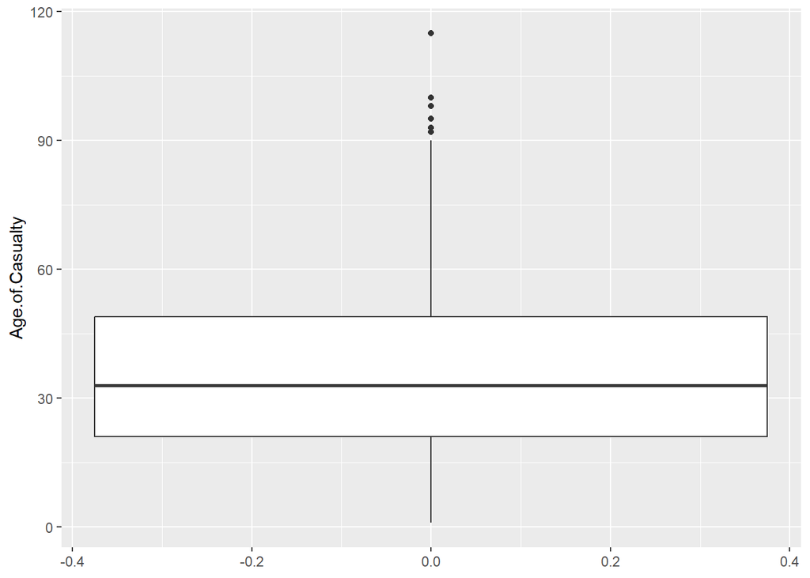

```r
filtered_data <- accidents[!is.na(accidents$Age.of.Casualty), ]

# Visual inspection with boxplot
ggplot(filtered_data, aes(y = Age.of.Casualty)) +
  geom_boxplot()
```

• Use 3-Sigma method

```r
age_of_casualty <- accidents$Age.of.Casualty
mean_age = mean(age_of_casualty, na.rm = TRUE)
sd_age = sd(age_of_casualty, na.rm = TRUE)
upper_bound <- mean_age + 3 * sd_age
lower_bound <- mean_age - 3 * sd_age
outliers_dataset <- accidents %>%
  filter(Age.of.Casualty < lower_bound | Age.of.Casualty > upper_bound)
number_of_outliers_sigma <- nrow(outliers_dataset)
print(paste("Number of outliers:", number_of_outliers_sigma))
```

```
## [1] "Number of outliers: 4"
```

```r
print(outliers_dataset)
```

```
##   Number.of.Vehicles Accident.Date Time..24hr. X1st.Road.Class Road.Surface
## 1                  2    2017-01-31       18:40    Unclassified     Wet/Damp
## 2                  1    2016-06-16       12:15               6          Dry
## 3                  1    2014-02-05       17:15               6   Wet / Damp
## 4                  2    2014-06-08       16:50               3          Dry
##                         Lighting.Conditions         Weather.Conditions
## 1 Darkness: street lights present but unlit Raining without high winds
## 2           Daylight: street lights present    Fine without high winds
## 3   Darkness: street lights present and lit    Fine without high winds
## 4           Daylight: street lights present    Fine without high winds
##   Type.of.Vehicle               Casualty.Class Casualty.Severity
## 1               9              Driver or rider           Serious
## 2               9                   Pedestrian            Slight
## 3               8                   Pedestrian           Serious
## 4               9 Vehicle or pillion passenger            Slight
##   Sex.of.Casualty Age.of.Casualty
## 1          Female             115
## 2            Male             100
## 3            Male              95
## 4          Female              98
```

• IQR

```r
# Calculate interquartile range (IQR) for Age_of_Casualty
Q1 <- quantile(filtered_data$Age.of.Casualty, 0.25, na.rm = TRUE)
Q3 <- quantile(filtered_data$Age.of.Casualty, 0.75, na.rm = TRUE)
IQR <- Q3 - Q1

# Calculate lower and upper bounds for outliers
lower_bound <- Q1 - 1.5 * IQR
upper_bound <- Q3 + 1.5 * IQR

# Identify outliers
outliers <- filtered_data[filtered_data$Age.of.Casualty < lower_bound | filtered_data$Age.of.Casualty > upper_bound, ]

# Print count of outliers
outliers  # or use dim(outliers)[1] for the number of rows
```

|  | Number.of.Vehicles | Accident.Date | Time..24hr. | X1st.Road.Class | Road.Surface | Lighting.Conditions | Weather.Conditions | Type.of.Vehicle | Casualty.Class | Casualty.Severity | Sex.of.Casualty | Age.of.Casualty |
| --- | --- | --- | --- | --- | --- | --- | --- | --- | --- | --- | --- | --- |
| 24 | 2 | 2017-01-31 | 18:40 | Unclassified | Wet/Damp | Darkness: street lights present but unlit | Raining without high winds | 9 | Driver or rider | Serious | Female | 115 |
| 146 | 1 | 2017-06-24 | 12:00 | A | Dry | Daylight: street lights present | Fine without high winds | 9 | Pedestrian | Serious | Male | 93 |
| 458 | 1 | 2016-03-19 | 19:02 | 6 | Dry | Daylight: street lights present | Fine without high winds | 9 | Pedestrian | Serious | Male | 93 |
| 617 | 1 | 2016-06-16 | 12:15 | 6 | Dry | Daylight: street lights present | Fine without high winds | 9 | Pedestrian | Slight | Male | 100 |
| 635 | 1 | 2016-06-28 | 16:27 | 3 | Dry | Daylight: street lights present | Fine without high winds | 9 | Pedestrian | Serious | Female | 92 |
| 1462 | 1 | 2014-02-05 | 17:15 | 6 | Wet / Damp | Darkness: street lights present and lit | Fine without high winds | 8 | Pedestrian | Serious | Male | 95 |
| 1722 | 2 | 2014-06-08 | 16:50 | 3 | Dry | Daylight: street lights present | Fine without high winds | 9 | Vehicle or pillion passenger | Slight | Female | 98 |

• Hampel Identifier

```r
# Extract Age of Casualty data
age_casualty <- filtered_data$Age.of.Casualty

# Calculate the median and MAD
median_age <- median(age_casualty, na.rm = TRUE)
mad_age <- mad(age_casualty, na.rm = TRUE)

# Calculate Hampel's upper and lower bounds
hampel_upper_bound <- median_age + 3 * mad_age
hampel_lower_bound <- median_age - 3 * mad_age

# Identify outliers using Hampel identifier
outliers_hampel <- age_casualty[age_casualty > hampel_upper_bound | age_casualty < hampel_lower_bound]

# Print the outliers
print(outliers_hampel)
```

```
## [1] 115  93  93 100  92  95  98
```

```r
# Create a dataset for Hampel outliers
outliers_hampel_dataset <- filtered_data %>%
  filter(Age.of.Casualty > hampel_upper_bound | Age.of.Casualty < hampel_lower_bound)

# Print the number of Hampel outliers
number_of_outliers_hampel <- nrow(outliers_hampel_dataset)
print(paste("Number of Hampel outliers:", number_of_outliers_hampel))
```

```
## [1] "Number of Hampel outliers: 7"
```

```r
# Print the Hampel outliers dataset
print(outliers_hampel_dataset)
```

```
##   Number.of.Vehicles Accident.Date Time..24hr. X1st.Road.Class Road.Surface
## 1                  2    2017-01-31       18:40    Unclassified     Wet/Damp
## 2                  1    2017-06-24       12:00               A          Dry
## 3                  1    2016-03-19       19:02               6          Dry
## 4                  1    2016-06-16       12:15               6          Dry
## 5                  1    2016-06-28       16:27               3          Dry
## 6                  1    2014-02-05       17:15               6   Wet / Damp
## 7                  2    2014-06-08       16:50               3          Dry
##                         Lighting.Conditions         Weather.Conditions
## 1 Darkness: street lights present but unlit Raining without high winds
## 2           Daylight: street lights present    Fine without high winds
## 3           Daylight: street lights present    Fine without high winds
## 4           Daylight: street lights present    Fine without high winds
## 5           Daylight: street lights present    Fine without high winds
## 6   Darkness: street lights present and lit    Fine without high winds
```

[output cut: 17 more lines]

```r
write.csv(filtered_data, file = "clean_accident.csv", row.names = FALSE)
```

# Data Exploration

• Load necessary packages

```r
# Note: Please run data Wrangling first
# Unknown error preventing this rmd file to be converted into html or pdf
library(ggplot2)
library(magrittr)
library(readr)
```

• Load the cleaned csv

```r
data <- read_csv("clean_accident.csv")
```

• Check the first 6 rows

```r
head(data)
```

| Number.of.Vehicles | Accident.Date | Time..24hr. | X1st.Road.Class | Road.Surface | Lighting.Conditions | Weather.Conditions | Type.of.Vehicle | Casualty.Class | Casualty.Severity | Sex.of.Casualty | Age.of.Casualty |
| --- | --- | --- | --- | --- | --- | --- | --- | --- | --- | --- | --- |
| 2 | 2017-01-01 | 21:20:00 | Unclassified | Wet/Damp | Darkness: street lights present and lit | Raining without high winds | 9 | Vehicle or pillion passenger | Serious | Female | 16 |
| 2 | 2017-01-04 | 15:00:00 | Unclassified | Dry | Daylight: street lights present | Fine without high winds | 9 | Pedestrian | Serious | Female | 67 |
| 2 | 2017-01-05 | 07:32:00 | A | Wet/Damp | Darkness: street lights present and lit | Fine without high winds | 9 | Driver or rider | Slight | Male | 56 |
| 2 | 2017-01-05 | 09:30:00 | A | Wet/Damp | Daylight: street lights present | Fine without high winds | 4 | Driver or rider | Fatal | Male | 20 |
| 2 | 2017-01-14 | 09:09:00 | Unclassified | Frost / Ice | Daylight: street lights present | Fine without high winds | 9 | Driver or rider | Slight | Male | 46 |
| 1 | 2017-01-16 | 10:59:00 | A | Wet/Damp | Daylight: street lights present | Fine without high winds | 9 | Pedestrian | Slight | Female | 25 |

• Check the structure of the data

```r
str(data)
```

```
## spc_tbl_ [2,050 × 12] (S3: spec_tbl_df/tbl_df/tbl/data.frame)
##  $ Number.of.Vehicles : num [1:2050] 2 2 2 2 2 1 3 1 1 2 ...
##  $ Accident.Date      : Date[1:2050], format: "2017-01-01" "2017-01-04" ...
##  $ Time..24hr.        : 'hms' num [1:2050] 21:20:00 15:00:00 07:32:00 09:30:00 ...
##   ..- attr(*, "units")= chr "secs"
##  $ X1st.Road.Class    : chr [1:2050] "Unclassified" "Unclassified" "A" "A" ...
##  $ Road.Surface       : chr [1:2050] "Wet/Damp" "Dry" "Wet/Damp" "Wet/Damp" ...
##  $ Lighting.Conditions: chr [1:2050] "Darkness: street lights present and lit" "Daylight: street lights present" "Darkness: street lights present and lit" "Daylight: street lights present" ...
##  $ Weather.Conditions : chr [1:2050] "Raining without high winds" "Fine without high winds" "Fine without high winds" "Fine without high winds" ...
##  $ Type.of.Vehicle    : num [1:2050] 9 9 9 4 9 9 9 9 9 9 ...
##  $ Casualty.Class     : chr [1:2050] "Vehicle or pillion passenger" "Pedestrian" "Driver or rider" "Driver or rider" ...
##  $ Casualty.Severity  : chr [1:2050] "Serious" "Serious" "Slight" "Fatal" ...
##  $ Sex.of.Casualty    : chr [1:2050] "Female" "Female" "Male" "Male" ...
##  $ Age.of.Casualty    : num [1:2050] 16 67 56 20 46 25 50 64 22 21 ...
##  - attr(*, "spec")=
##   .. cols(
##   ..   Number.of.Vehicles = col_double(),
##   ..   Accident.Date = col_date(format = ""),
##   ..   Time..24hr. = col_time(format = ""),
##   ..   X1st.Road.Class = col_character(),
##   ..   Road.Surface = col_character(),
##   ..   Lighting.Conditions = col_character(),
##   ..   Weather.Conditions = col_character(),
##   ..   Type.of.Vehicle = col_double(),
##   ..   Casualty.Class = col_character(),
##   ..   Casualty.Severity = col_character(),
##   ..   Sex.of.Casualty = col_character(),
##   ..   Age.of.Casualty = col_double()
##   .. )
##  - attr(*, "problems")=<externalptr>
```

```r
male_accidents <- accidents %>%
  filter(Casualty.Class == "Driver or rider", Sex.of.Casualty == "Male")

female_accidents <- accidents %>%
  filter(Casualty.Class == "Driver or rider", Sex.of.Casualty == "Female")

count(male_accidents)
```

| n |
| --- |
| 829 |

```r
count(female_accidents)
```

| n |
| --- |
| 396 |

• Group the data by weather

```r
male_counts <- male_accidents %>%
  group_by(Weather.Conditions) %>%
  summarise(total_male_accidents = n())

female_counts <- female_accidents %>%
  group_by(Weather.Conditions) %>%
  summarise(total_female_accidents = n())
```

```r
accident_comparison <- merge(male_counts, female_counts, by = "Weather.Conditions", all = TRUE)

# Calculate the difference where males have more accidents than females
accident_comparison <- accident_comparison %>%
  mutate(more_male_accidents = ifelse(total_male_accidents > total_female_accidents,
                                      total_male_accidents - total_female_accidents,
                                      0))

# Filter for cases where males have more accidents than females
more_accidents <- accident_comparison %>%
  filter(more_male_accidents > 0) %>%
  arrange(desc(more_male_accidents))  # Sort by descending difference
```

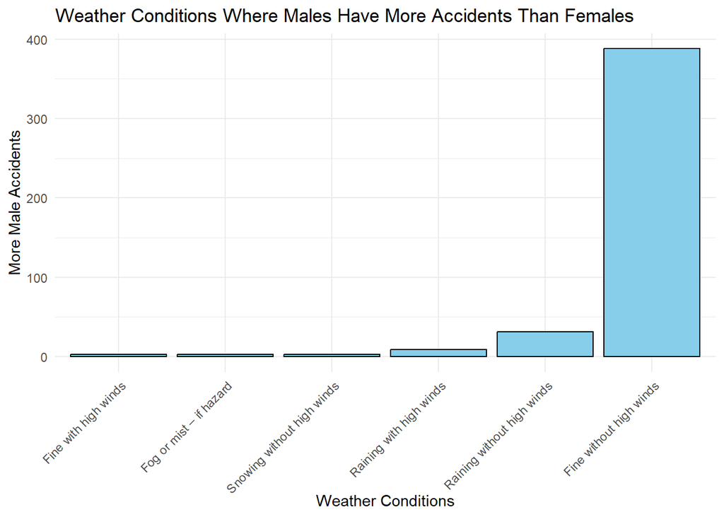

```r
# Create a bar plot using ggplot2
ggplot(more_accidents, aes(x = reorder(Weather.Conditions, more_male_accidents), y = more_male_accidents)) +
  geom_bar(stat = "identity", fill = "skyblue", color = "black") +
  labs(x = "Weather Conditions", y = "More Male Accidents") +
  ggtitle("Weather Conditions Where Males Have More Accidents Than Females") +
  theme_minimal() +
  theme(axis.text.x = element_text(angle = 45, hjust = 1))
```

```r
number_of_cases <- nrow(more_accidents)
number_of_cases
```

```
## [1] 6
```

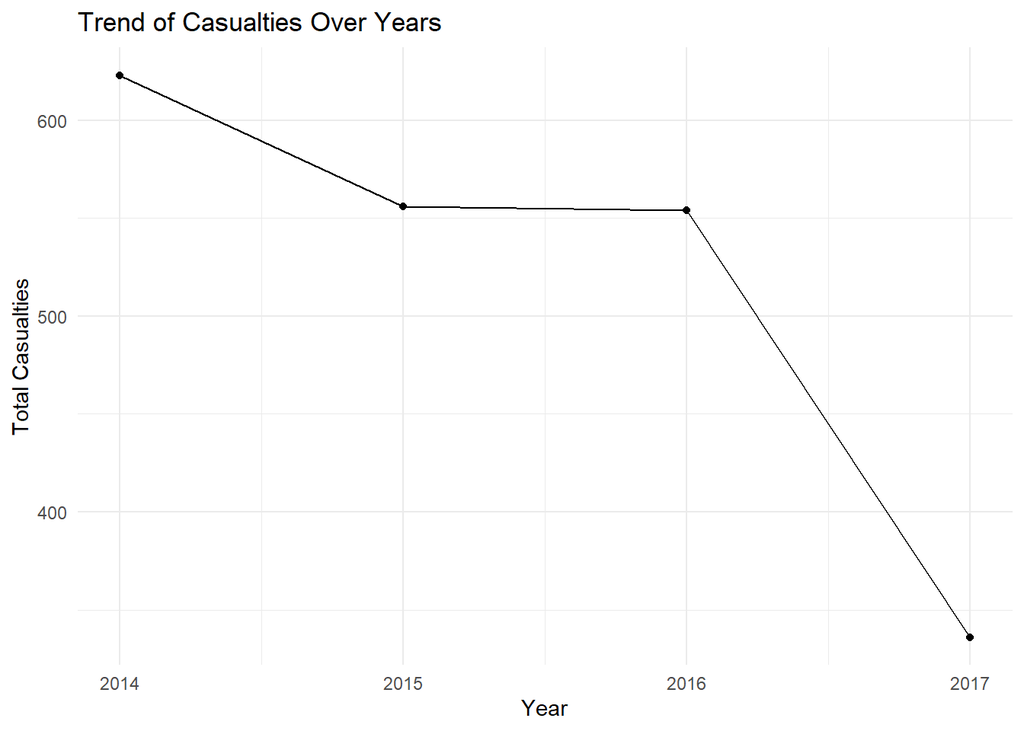

```r
accidents <- accidents %>%
  mutate(Year = lubridate::year(Accident.Date))

# Group by year and count casualties
casualties_by_year <- accidents %>%
  group_by(Year) %>%
  summarise(total_casualties = n())

# Find the year with the highest number of casualties
max_casualty_year <- casualties_by_year %>%
  filter(total_casualties == max(total_casualties)) %>%
  pull(Year)

# Plotting the trend of casualties over the years
ggplot(casualties_by_year, aes(x = Year, y = total_casualties)) +
  geom_line() +
  geom_point() +
  labs(title = "Trend of Casualties Over Years",
       x = "Year",
       y = "Total Casualties") +
  theme_minimal()
```

```r
# Print the year with the highest number of casualties
print(paste("Year with the highest number of casualties:", max_casualty_year))
```

```
## [1] "Year with the highest number of casualties: 2014"
```

### Light condition and Severity

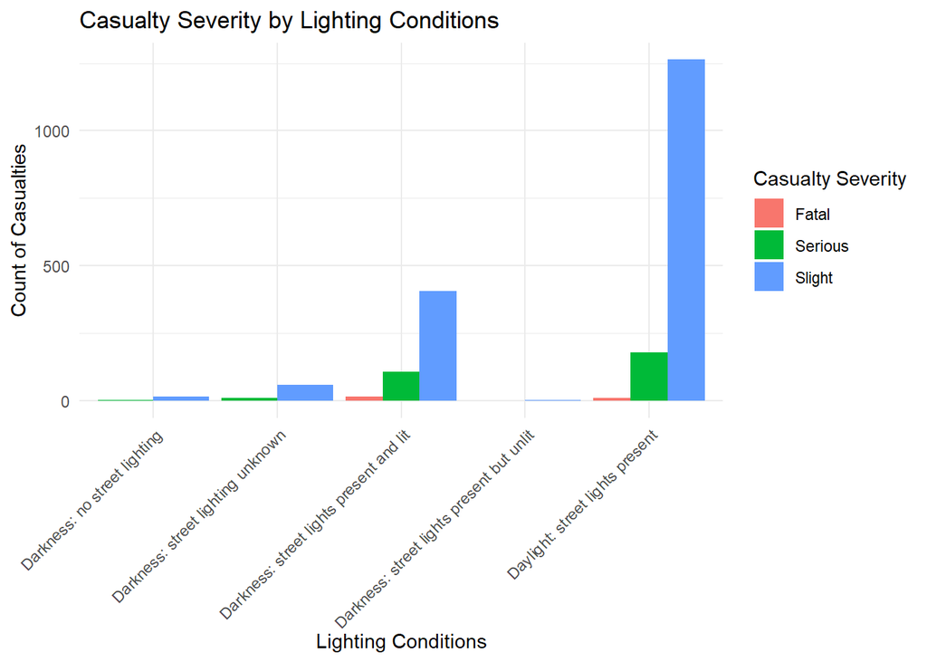

```r
# Load necessary libraries
library(ggplot2)
library(dplyr)

# Assuming 'accidents' dataset is already loaded and cleaned

# Create the bar plot for Light Conditions and Severity
light_severity_plot <- ggplot(accidents, aes(x = Lighting.Conditions, fill = Casualty.Severity)) +
  geom_bar(position = "dodge") +  # Create a bar plot with bars side by side for each severity level
  labs(title = "Casualty Severity by Lighting Conditions",
       x = "Lighting Conditions",
       y = "Count of Casualties",
       fill = "Casualty Severity") +
  theme_minimal() +
  theme(axis.text.x = element_text(angle = 45, hjust = 1))  # Rotate x-axis labels for better readability

# Print the plot
print(light_severity_plot)
```

```r
# Check the count of casualties by lighting conditions and severity
table(accidents$Lighting.Conditions, accidents$Casualty.Severity)
```

```
##
##                                             Fatal Serious Slight
##   Darkness: no street lighting                  0       3     15
##   Darkness: street lighting unknown             0      10     59
##   Darkness: street lights present and lit      15     107    405
##   Darkness: street lights present but unlit     0       1      3
##   Daylight: street lights present              10     178   1263
```

##### Interpretation

###### Darkness with no streetlight:

There is no fatal injury and only few seriously injured with a slightly higher number minorly injured

###### Darkness: street lighting unknown

Although no fatal injuries, the number of seriously and slightly injured has tripled compared to darkness with no streetlight.

###### Darkness: street lights present and lit

The lit streetlight at darkness has the highest number of fatal injuries (15), 107 seriously injured and 405 slightly injured. The reason might be because of low volume of traffic at night and well lit streets.

###### Darkness: street lights present but unlit

The unlit streetlight in darkness has the lowest number of injuries overall(0 fatal, 1 serious, 3 slight). The reason might be because of although low traffic, but low visibility as well.

###### Daylight: street lights present

Shows the highest number of accidents in every category except fatality(10 fatal, 178 serious, 1263). The plausible reason might be high volume of traffic and better visibility of accidents happening on the broad daylight.

###### Other 2 conditions (Daylight: no street lights present and Daylight: streetlight unknown) has 0 number of casualties as the obvious reason being no streetlight being lit during the daytime.

### Weather and number of vehicles involved

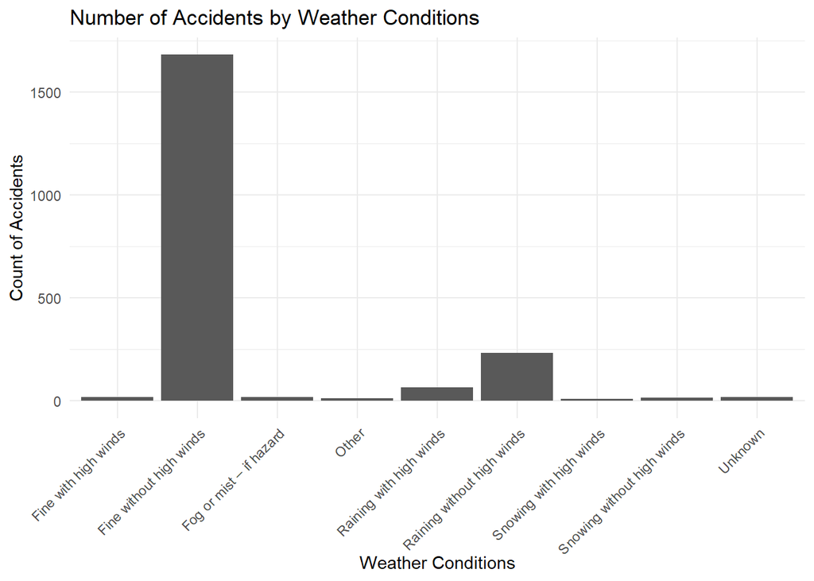

```r
weather_vehicles_count_data <- accidents %>%
  group_by(Weather.Conditions) %>%
  summarise(Count_of_Accidents = n())

weather_vehicles_plot <- ggplot(weather_vehicles_count_data, aes(x = Weather.Conditions, y = Count_of_Accidents)) +
  geom_bar(stat = "identity") +
  labs(title = "Number of Accidents by Weather Conditions",
       x = "Weather Conditions",
       y = "Count of Accidents") +
  theme_minimal() +
  theme(axis.text.x = element_text(angle = 45, hjust = 1))

weather_vehicles_plot
```

##### Interpretation

###### Raining without high winds:

Although not as severe as fine without high winds, the number of vehicles involved in accident is noticeable (250). The most probable reason cold be more cautious driving during rain as the tires may slip.

###### Others (everything except aforementioned):

```r
table(accidents$Weather.Conditions, accidents$Number.of.Vehicles)
```

```
##
##                                1   2   3   4   5   6   7
##   Fine with high winds         7  10   0   0   0   0   0
##   Fine without high winds    494 950 170  44   8   5  10
##   Fog or mist – if hazard      6  10   2   0   0   0   0
##   Other                        4   6   2   0   0   0   0
##   Raining with high winds     19  35   7   4   0   0   0
##   Raining without high winds  71 123  37   2   0   0   0
##   Snowing with high winds      2   4   2   0   0   0   0
##   Snowing without high winds   6   6   3   1   0   0   0
##   Unknown                      6  12   1   0   0   0   0
```

# Linear Regression

• Load necessary libraries

```r
library(dplyr)
library(magrittr)
library(tidyverse)
```

```r
data <- read.csv('data/accidents.csv')
head(data)
```

|  | Number.of.Vehicles | Accident.Date | Time..24hr. | X1st.Road.Class | Road.Surface | Lighting.Conditions | Daylight.Dark | Weather.Conditions | Local.Authority | Type.of.Vehicle | Casualty.Class | Casualty.Severity | Sex.of.Casualty | Age.of.Casualty |
| --- | --- | --- | --- | --- | --- | --- | --- | --- | --- | --- | --- | --- | --- | --- |
| 1 | 2 | 1/1/2017 | 2120 | U | Wet/Damp | 4 | Dark | 2 | Calderdale | 9 | 2 | 2 | 2 | 16 |
| 2 | 2 | 4/1/2017 | 1500 | U | Dry | 1 | Daylight | 1 | Calderdale | 9 | 3 | 2 | 2 | 67 |
| 3 | 2 | 5/1/2017 | 732 | A58 | Wet/Damp | 4 | Dark | 1 | Calderdale | 9 | 1 | 3 | 1 | 56 |
| 4 | 2 | 5/1/2017 | 930 | A646 | Wet/Damp | 1 | Daylight | 1 | Calderdale | 4 | 1 | 1 | 1 | 20 |
| 5 | 2 | 14/01/2017 | 909 | U | Frost/Ice | 1 | Daylight | 1 | Calderdale | 9 | 1 | 3 | 1 | 46 |
| 6 | 1 | 15/01/2017 | 1659 | U | Wet/Damp | 4 | Dark | 1 | Calderdale | 9 | 3 | 3 | 1 | NA |

• Check the structure of data

```r
str(data)
```

```
## 'data.frame':    2069 obs. of  14 variables:
##  $ Number.of.Vehicles : int  2 2 2 2 2 1 1 3 1 1 ...
##  $ Accident.Date      : chr  "1/1/2017" "4/1/2017" "5/1/2017" "5/1/2017" ...
##  $ Time..24hr.        : int  2120 1500 732 930 909 1659 1059 1849 1408 1325 ...
##  $ X1st.Road.Class    : chr  "U" "U" "A58" "A646" ...
##  $ Road.Surface       : chr  "Wet/Damp" "Dry" "Wet/Damp" "Wet/Damp" ...
##  $ Lighting.Conditions: int  4 1 4 1 1 4 1 4 1 1 ...
##  $ Daylight.Dark      : chr  "Dark" "Daylight" "Dark" "Daylight" ...
##  $ Weather.Conditions : int  2 1 1 1 1 1 1 1 1 1 ...
##  $ Local.Authority    : chr  "Calderdale" "Calderdale" "Calderdale" "Calderdale" ...
##  $ Type.of.Vehicle    : int  9 9 9 4 9 9 9 9 9 9 ...
##  $ Casualty.Class     : int  2 3 1 1 1 3 3 1 3 1 ...
##  $ Casualty.Severity  : int  2 2 3 1 3 3 3 3 3 3 ...
##  $ Sex.of.Casualty    : int  2 2 1 1 1 1 2 2 2 2 ...
##  $ Age.of.Casualty    : int  16 67 56 20 46 NA 25 50 64 22 ...
```

• Convert columns into something usable

```r
data$Casualty.Class <- as.factor(data$Casualty.Class)
data$Casualty.Severity <- as.factor(data$Casualty.Severity)
data$Type.of.Vehicle <- as.factor(data$Type.of.Vehicle)
data$Weather.Conditions <- as.factor(data$Weather.Conditions)
str(data)
```

```
## 'data.frame':    2069 obs. of  14 variables:
##  $ Number.of.Vehicles : int  2 2 2 2 2 1 1 3 1 1 ...
##  $ Accident.Date      : chr  "1/1/2017" "4/1/2017" "5/1/2017" "5/1/2017" ...
##  $ Time..24hr.        : int  2120 1500 732 930 909 1659 1059 1849 1408 1325 ...
##  $ X1st.Road.Class    : chr  "U" "U" "A58" "A646" ...
##  $ Road.Surface       : chr  "Wet/Damp" "Dry" "Wet/Damp" "Wet/Damp" ...
##  $ Lighting.Conditions: int  4 1 4 1 1 4 1 4 1 1 ...
##  $ Daylight.Dark      : chr  "Dark" "Daylight" "Dark" "Daylight" ...
##  $ Weather.Conditions : Factor w/ 9 levels "1","2","3","4",..: 2 1 1 1 1 1 1 1 1 1 ...
##  $ Local.Authority    : chr  "Calderdale" "Calderdale" "Calderdale" "Calderdale" ...
##  $ Type.of.Vehicle    : Factor w/ 19 levels "1","2","3","4",..: 7 7 7 4 7 7 7 7 7 7 ...
##  $ Casualty.Class     : Factor w/ 3 levels "1","2","3": 2 3 1 1 1 3 3 1 3 1 ...
##  $ Casualty.Severity  : Factor w/ 3 levels "1","2","3": 2 2 3 1 3 3 3 3 3 3 ...
##  $ Sex.of.Casualty    : int  2 2 1 1 1 1 2 2 2 2 ...
##  $ Age.of.Casualty    : int  16 67 56 20 46 NA 25 50 64 22 ...
```

• Create a data to train

```r
train.data <- data
head(train.data)
```

|  | Number.of.Vehicles | Accident.Date | Time..24hr. | X1st.Road.Class | Road.Surface | Lighting.Conditions | Daylight.Dark | Weather.Conditions | Local.Authority | Type.of.Vehicle | Casualty.Class | Casualty.Severity | Sex.of.Casualty | Age.of.Casualty |
| --- | --- | --- | --- | --- | --- | --- | --- | --- | --- | --- | --- | --- | --- | --- |
| 1 | 2 | 1/1/2017 | 2120 | U | Wet/Damp | 4 | Dark | 2 | Calderdale | 9 | 2 | 2 | 2 | 16 |
| 2 | 2 | 4/1/2017 | 1500 | U | Dry | 1 | Daylight | 1 | Calderdale | 9 | 3 | 2 | 2 | 67 |
| 3 | 2 | 5/1/2017 | 732 | A58 | Wet/Damp | 4 | Dark | 1 | Calderdale | 9 | 1 | 3 | 1 | 56 |
| 4 | 2 | 5/1/2017 | 930 | A646 | Wet/Damp | 1 | Daylight | 1 | Calderdale | 4 | 1 | 1 | 1 | 20 |
| 5 | 2 | 14/01/2017 | 909 | U | Frost/Ice | 1 | Daylight | 1 | Calderdale | 9 | 1 | 3 | 1 | 46 |
| 6 | 1 | 15/01/2017 | 1659 | U | Wet/Damp | 4 | Dark | 1 | Calderdale | 9 | 3 | 3 | 1 | NA |

• Create a linear model

```r
lm.model <- lm(Age.of.Casualty ~ Casualty.Class + Casualty.Severity
               + Type.of.Vehicle + Weather.Conditions, data = train.data)

summary(lm.model)
```

```
##
## Call:
## lm(formula = Age.of.Casualty ~ Casualty.Class + Casualty.Severity +
##     Type.of.Vehicle + Weather.Conditions, data = train.data)
##
## Residuals:
##     Min      1Q  Median      3Q     Max
## -41.011 -13.836  -3.836  11.372  74.470
##
## Coefficients:
##                      Estimate Std. Error t value Pr(>|t|)
## (Intercept)          39.24578    4.09485   9.584  < 2e-16 ***
## Casualty.Class2     -10.33801    1.08903  -9.493  < 2e-16 ***
## Casualty.Class3      -5.74153    1.17441  -4.889 1.09e-06 ***
## Casualty.Severity2   -0.79086    3.95306  -0.200 0.841453
## Casualty.Severity3   -3.62004    3.83488  -0.944 0.345294
## Type.of.Vehicle2    -11.23831    4.42569  -2.539 0.011181 *
## Type.of.Vehicle3     -7.88001    2.83980  -2.775 0.005574 **
## Type.of.Vehicle4      1.87081    4.44414   0.421 0.673827
## Type.of.Vehicle5      6.58660    2.95297   2.231 0.025824 *
## Type.of.Vehicle8      6.55257    2.74807   2.384 0.017198 *
## Type.of.Vehicle9      4.20993    1.72319   2.443 0.014647 *
## Type.of.Vehicle10     9.20195   11.06713   0.831 0.405808
## Type.of.Vehicle11    16.29740    3.60651   4.519 6.58e-06 ***
## Type.of.Vehicle16    -4.62574   13.46905  -0.343 0.731307
## Type.of.Vehicle17   -11.62574   13.46905  -0.863 0.388160
## Type.of.Vehicle18    -6.73373   11.06074  -0.609 0.542728
## Type.of.Vehicle19     4.78531    2.89890   1.651 0.098949 .
## Type.of.Vehicle20    21.21183    6.90388   3.072 0.002151 **
## Type.of.Vehicle21    15.44571    4.45327   3.468 0.000535 ***
## Type.of.Vehicle22    14.37426   18.97931   0.757 0.448920
## Type.of.Vehicle23   -19.62574   18.97931  -1.034 0.301232
## Type.of.Vehicle90    -0.09675    6.53025  -0.015 0.988181
## Type.of.Vehicle97    45.11580   19.01769   2.372 0.017771 *
## Weather.Conditions2  -2.13510    1.33965  -1.594 0.111143
## Weather.Conditions3   2.18770    4.76285   0.459 0.646051
## Weather.Conditions4   3.89607    4.62454   0.842 0.399620
## Weather.Conditions5  -3.39275    2.42242  -1.401 0.161499
## Weather.Conditions6   1.21828    6.71970   0.181 0.856150
## Weather.Conditions7   2.08722    4.49335   0.465 0.642331
## Weather.Conditions8 -11.20213    5.48830  -2.041 0.041371 *
## Weather.Conditions9  -3.40685    4.37942  -0.778 0.436706
## ---
## Signif. codes:  0 '***' 0.001 '**' 0.01 '*' 0.05 '.' 0.1 ' ' 1
##
## Residual standard error: 18.91 on 2019 degrees of freedom
##   (19 observations deleted due to missingness)
## Multiple R-squared:  0.0784, Adjusted R-squared:  0.06471
## F-statistic: 5.725 on 30 and 2019 DF,  p-value: < 2.2e-16
```

• Filter data with missing values

```r
missing.data <- data %>%
  filter(is.na(Age.of.Casualty))
```

• Predict the missing values

```r
predicted.age <- predict(lm.model, newdata = missing.data)

data$Age.of.Casualty[is.na(data$Age.of.Casualty)] <- predicted.age

missing.data <- data %>%
  filter(is.na(Age.of.Casualty))
missing.data
```

| Number.of.Vehicles | Accident.Date | Time..24hr. | X1st.Road.Class | Road.Surface | Lighting.Conditions | Daylight.Dark | Weather.Conditions | Local.Authority | Type.of.Vehicle | Casualty.Class | Casualty.Severity | Sex.of.Casualty | Age.of.Casualty |
| --- | --- | --- | --- | --- | --- | --- | --- | --- | --- | --- | --- | --- | --- |

• Round up the predicted value and convert it to integer

```r
data$Age.of.Casualty <- round(data$Age.of.Casualty)

data$Age.of.Casualty <- as.integer(data$Age.of.Casualty)
```

• Check for any remaining missing values in the dataset

```r
missing.values <- colSums(is.na(data))
print(missing.values[missing.values > 0])
```

```
## named numeric(0)
```

```r
dim(data)
```

```
## [1] 2069   14
```

```r
write.csv(data, "regression.csv", row.names = FALSE, quote= FALSE, fileEncoding = "UTF-8")
```